# Polychoric correlations — SUS, UEQ, Cognitive value, Intuitiveness, Visualization

## Item groups

- **SUS**: `SUS_1`–`SUS_10`
- **UEQ_pragmatic**: `UEQ_1`–`UEQ_4`
- **UEQ_hedonic**: `UEQ_5`–`UEQ_8`
- **Cognitive_value**: `P064`, `P301`, `P060`, `P027`
- **Intuitiveness**: `P088`, `P026`, `P4026A`
- **Visualization**: `P106`, `P089`, `P098`, `P097`, `P022A`, `P067`

```
## Items used in this run (params$scales): uxvis
```

```r
df <- read.csv(
  input_file,
  stringsAsFactors = FALSE,
  na.strings = c("NA", ""),
  check.names = FALSE
)

uxvis_groups <- list(
  Cognitive_value = c("P064", "P301", "P060", "P027"),
  Intuitiveness   = c("P088", "P026", "P4026A"),
  Visualization   = c("P106", "P089", "P098", "P097", "P022A", "P067")
)
gold_standard_groups <- list(
  SUS             = c("SUS_1", "SUS_2", "SUS_3", "SUS_4", "SUS_5",
                       "SUS_6", "SUS_7", "SUS_8", "SUS_9", "SUS_10"),
  UEQ_pragmatic   = c("UEQ_1", "UEQ_2", "UEQ_3", "UEQ_4"),
  UEQ_hedonic     = c("UEQ_5", "UEQ_6", "UEQ_7", "UEQ_8")
)

item_groups <- if (params$scales == "all") c(gold_standard_groups, uxvis_groups) else uxvis_groups

item_to_group <- data.frame(
  item  = unlist(item_groups, use.names = FALSE),
  group = rep(names(item_groups), lengths(item_groups)),
  stringsAsFactors = FALSE
)

all_items <- item_to_group$item

all_colors <- c(SUS = "#5E4EA3", UEQ_pragmatic = "#379EB8", UEQ_hedonic = "#4AAF77",
                Cognitive_value = "#E02884", Intuitiveness = "#F06128", Visualization = "#E2A600")
group_colors <- all_colors[names(item_groups)]
```

## Compute polychoric correlations (pairwise deletion)

`hetcor(..., use = "pairwise.complete.obs")` estimates each pairwise correlation from only the rows where *that specific pair* of items is non-missing (pairwise deletion), rather than dropping a participant from the whole matrix because a single item elsewhere is missing. Every item is coerced to an ordered factor first, so every pair is estimated as a genuine polychoric correlation (not Pearson or polyserial).

`std.err` is left off: computing polychoric standard errors requires a numerical Hessian, and its finite-difference probing routinely pushes the bivariate-normal CDF differences into underflow, producing `"NaNs produced"` warnings across most pairs. The `r` estimates themselves are unaffected — only that Hessian step is unstable. Significance is instead approximated below with the same t-approximation used for Pearson correlations (`t = r * sqrt(n-2) / sqrt(1-r^2)`, `df = n-2`); this is a standard practical stand-in for polychoric significance testing, not an exact analytic result.

`SUS_2, SUS_4, SUS_6, SUS_8, SUS_10` are the negatively-worded SUS items (Brooke, 1996) — on the 1–5 raw scale, a *higher* raw score means *worse* usability for these five, opposite every other item in the matrix. They’re reverse-coded (`6 - score`) before scoring, so every item in the resulting matrix points the same “more positive” direction and signs are directly comparable across the whole matrix (matches the reverse-coding already applied to the SUS composite in the Pearson notebook).

```r
reverse_items <- c("SUS_2", "SUS_4", "SUS_6", "SUS_8", "SUS_10")

# 1. Select only targeting columns
item_df <- df[, all_items]

# 2. Invert SUS negative items (1-5 -> 6 - value)
#
for (col in reverse_items) {
  if (col %in% colnames(item_df)) {
    item_df[[col]] <- 6 - as.numeric(item_df[[col]])
  }
}

# 3. Convert all columns to ordered factors
item_df <- as.data.frame(lapply(item_df, ordered))

# 4. Executa a correlação policórica
het <- polycor::hetcor(item_df, use = "pairwise.complete.obs", std.err = FALSE, ML = FALSE)
```

```r
#r_mat <- het$correlations[all_items, all_items]  # enforce construct-block order
#n_mat <- het$n[all_items, all_items]

# Compute the correct pairwise sample size matrix (N)
#valid_data <- !is.na(item_df[, all_items])
#n_mat <- t(valid_data) %*% valid_data
#dimnames(n_mat) <- dimnames(r_mat)


#t_mat <- r_mat * sqrt(n_mat - 2) / sqrt(1 - r_mat^2)


#p_raw <- 2 * pt(-abs(t_mat), df = n_mat - 2)
#p_mat <- matrix(p_raw, nrow = nrow(r_mat), ncol = ncol(r_mat), dimnames = dimnames(r_mat))
#diag(p_mat) <- NA  # self-correlation (r = 1) makes t = Inf/NaN; not a meaningful p-value anyway

#groups_vec <- item_to_group$group[match(colnames(r_mat), item_to_group$item)]


#axis_text_element <- function(colors, angle = 0, hjust = 0.5, vjust = 0.5) {
#  element_text(angle = angle, hjust = hjust, vjust = vjust, colour = colors, face = "bold")
#}


r_mat <- het$correlations[all_items, all_items]  # enforce construct-block order

# Compute the correct pairwise sample size matrix (N)
valid_data <- as.matrix(!is.na(item_df[, all_items])) * 1
n_mat <- t(valid_data) %*% valid_data
dimnames(n_mat) <- dimnames(r_mat)

# Approximated t-test and p-values
t_mat <- r_mat * sqrt(n_mat - 2) / sqrt(1 - r_mat^2)
p_raw <- 2 * pt(-abs(t_mat), df = n_mat - 2)
p_mat <- matrix(p_raw, nrow = nrow(r_mat), ncol = ncol(r_mat), dimnames = dimnames(r_mat))
diag(p_mat) <- NA

groups_vec <- item_to_group$group[match(colnames(r_mat), item_to_group$item)]

# Theme helper for axis labels
axis_text_element <- function(colors, angle = 0, hjust = 0.5, vjust = 0.5, size = 12) {
  ggplot2::element_text(angle = angle, hjust = hjust, vjust = vjust, colour = colors, face = "bold", size = size)
}
```

## Results — long table

```r
long <- as.data.frame(as.table(r_mat)) %>%
  rename(item1 = Var1, item2 = Var2, r = Freq) %>%
  filter(as.character(item1) < as.character(item2)) %>%
  mutate(
    group1 = item_to_group$group[match(as.character(item1), item_to_group$item)],
    group2 = item_to_group$group[match(as.character(item2), item_to_group$item)],
    within_construct = group1 == group2
  )

# Vectorized lookup via an integer index matrix (guaranteed to return a plain
# numeric vector, unlike mapply() over factor columns, which can degrade to a
# list column that write.csv() then can't serialize).
i_idx <- match(as.character(long$item1), colnames(p_mat))
j_idx <- match(as.character(long$item2), colnames(p_mat))
long$p <- p_mat[cbind(i_idx, j_idx)]
long$n <- n_mat[cbind(i_idx, j_idx)]

long <- long %>% arrange(group1, group2, item1, item2)

kable(long, digits = c(NA, NA, 3, NA, NA, NA, 4, 0))
```

| item1 | item2 | r | group1 | group2 | within_construct | p | n |
| --- | --- | --- | --- | --- | --- | --- | --- |
| P064 | P301 | 0.408 | Cognitive_value | Cognitive_value | TRUE | 0.0000 | 225 |
| P060 | P064 | 0.589 | Cognitive_value | Cognitive_value | TRUE | 0.0000 | 225 |
| P060 | P301 | 0.546 | Cognitive_value | Cognitive_value | TRUE | 0.0000 | 226 |
| P027 | P064 | 0.357 | Cognitive_value | Cognitive_value | TRUE | 0.0000 | 224 |
| P027 | P301 | 0.621 | Cognitive_value | Cognitive_value | TRUE | 0.0000 | 225 |
| P027 | P060 | 0.491 | Cognitive_value | Cognitive_value | TRUE | 0.0000 | 225 |
| P064 | P088 | 0.300 | Cognitive_value | Intuitiveness | FALSE | 0.0000 | 225 |
| P064 | P4026A | 0.282 | Cognitive_value | Intuitiveness | FALSE | 0.0000 | 225 |
| P301 | P4026A | 0.299 | Cognitive_value | Intuitiveness | FALSE | 0.0000 | 226 |
| P060 | P088 | 0.528 | Cognitive_value | Intuitiveness | FALSE | 0.0000 | 226 |
| P060 | P4026A | 0.499 | Cognitive_value | Intuitiveness | FALSE | 0.0000 | 226 |
| P027 | P088 | 0.501 | Cognitive_value | Intuitiveness | FALSE | 0.0000 | 225 |
| P027 | P4026A | 0.427 | Cognitive_value | Intuitiveness | FALSE | 0.0000 | 225 |
| P064 | P106 | 0.176 | Cognitive_value | Visualization | FALSE | 0.0084 | 223 |
| P064 | P089 | 0.342 | Cognitive_value | Visualization | FALSE | 0.0000 | 225 |
| P064 | P098 | 0.379 | Cognitive_value | Visualization | FALSE | 0.0000 | 225 |
| P064 | P097 | 0.427 | Cognitive_value | Visualization | FALSE | 0.0000 | 225 |
| P064 | P067 | 0.436 | Cognitive_value | Visualization | FALSE | 0.0000 | 224 |
| P060 | P106 | 0.153 | Cognitive_value | Visualization | FALSE | 0.0222 | 224 |
| P060 | P089 | 0.389 | Cognitive_value | Visualization | FALSE | 0.0000 | 226 |
| P060 | P098 | 0.310 | Cognitive_value | Visualization | FALSE | 0.0000 | 226 |
| P060 | P097 | 0.435 | Cognitive_value | Visualization | FALSE | 0.0000 | 226 |
| P060 | P067 | 0.394 | Cognitive_value | Visualization | FALSE | 0.0000 | 225 |
| P027 | P106 | 0.463 | Cognitive_value | Visualization | FALSE | 0.0000 | 223 |
| P027 | P089 | 0.464 | Cognitive_value | Visualization | FALSE | 0.0000 | 225 |
| P027 | P098 | 0.466 | Cognitive_value | Visualization | FALSE | 0.0000 | 225 |
| P027 | P097 | 0.477 | Cognitive_value | Visualization | FALSE | 0.0000 | 225 |
| P027 | P067 | 0.409 | Cognitive_value | Visualization | FALSE | 0.0000 | 224 |
| P088 | P301 | 0.339 | Intuitiveness | Cognitive_value | FALSE | 0.0000 | 226 |
| P026 | P064 | 0.304 | Intuitiveness | Cognitive_value | FALSE | 0.0000 | 225 |
| P026 | P301 | 0.217 | Intuitiveness | Cognitive_value | FALSE | 0.0010 | 226 |
| P026 | P060 | 0.452 | Intuitiveness | Cognitive_value | FALSE | 0.0000 | 226 |
| P026 | P027 | 0.444 | Intuitiveness | Cognitive_value | FALSE | 0.0000 | 225 |
| P088 | P4026A | 0.685 | Intuitiveness | Intuitiveness | TRUE | 0.0000 | 226 |
| P026 | P088 | 0.795 | Intuitiveness | Intuitiveness | TRUE | 0.0000 | 226 |
| P026 | P4026A | 0.667 | Intuitiveness | Intuitiveness | TRUE | 0.0000 | 226 |
| P088 | P106 | 0.360 | Intuitiveness | Visualization | FALSE | 0.0000 | 224 |
| P088 | P089 | 0.507 | Intuitiveness | Visualization | FALSE | 0.0000 | 226 |
| P088 | P098 | 0.343 | Intuitiveness | Visualization | FALSE | 0.0000 | 226 |
| P088 | P097 | 0.299 | Intuitiveness | Visualization | FALSE | 0.0000 | 226 |
| P026 | P106 | 0.293 | Intuitiveness | Visualization | FALSE | 0.0000 | 224 |
| P026 | P089 | 0.467 | Intuitiveness | Visualization | FALSE | 0.0000 | 226 |
| P026 | P098 | 0.290 | Intuitiveness | Visualization | FALSE | 0.0000 | 226 |
| P026 | P097 | 0.315 | Intuitiveness | Visualization | FALSE | 0.0000 | 226 |
| P026 | P067 | 0.395 | Intuitiveness | Visualization | FALSE | 0.0000 | 225 |
| P106 | P301 | 0.440 | Visualization | Cognitive_value | FALSE | 0.0000 | 224 |
| P089 | P301 | 0.361 | Visualization | Cognitive_value | FALSE | 0.0000 | 226 |
| P098 | P301 | 0.553 | Visualization | Cognitive_value | FALSE | 0.0000 | 226 |
| P097 | P301 | 0.484 | Visualization | Cognitive_value | FALSE | 0.0000 | 226 |
| P022A | P064 | 0.277 | Visualization | Cognitive_value | FALSE | 0.0000 | 225 |
| P022A | P301 | 0.334 | Visualization | Cognitive_value | FALSE | 0.0000 | 226 |
| P022A | P060 | 0.289 | Visualization | Cognitive_value | FALSE | 0.0000 | 226 |
| P022A | P027 | 0.374 | Visualization | Cognitive_value | FALSE | 0.0000 | 225 |
| P067 | P301 | 0.281 | Visualization | Cognitive_value | FALSE | 0.0000 | 225 |
| P106 | P4026A | 0.288 | Visualization | Intuitiveness | FALSE | 0.0000 | 224 |
| P089 | P4026A | 0.411 | Visualization | Intuitiveness | FALSE | 0.0000 | 226 |
| P098 | P4026A | 0.248 | Visualization | Intuitiveness | FALSE | 0.0002 | 226 |
| P097 | P4026A | 0.376 | Visualization | Intuitiveness | FALSE | 0.0000 | 226 |
| P022A | P088 | 0.462 | Visualization | Intuitiveness | FALSE | 0.0000 | 226 |
| P022A | P026 | 0.440 | Visualization | Intuitiveness | FALSE | 0.0000 | 226 |
| P022A | P4026A | 0.454 | Visualization | Intuitiveness | FALSE | 0.0000 | 226 |
| P067 | P088 | 0.358 | Visualization | Intuitiveness | FALSE | 0.0000 | 225 |
| P067 | P4026A | 0.351 | Visualization | Intuitiveness | FALSE | 0.0000 | 225 |
| P089 | P106 | 0.356 | Visualization | Visualization | TRUE | 0.0000 | 224 |
| P089 | P098 | 0.471 | Visualization | Visualization | TRUE | 0.0000 | 226 |
| P089 | P097 | 0.423 | Visualization | Visualization | TRUE | 0.0000 | 226 |
| P098 | P106 | 0.585 | Visualization | Visualization | TRUE | 0.0000 | 224 |
| P097 | P106 | 0.520 | Visualization | Visualization | TRUE | 0.0000 | 224 |
| P097 | P098 | 0.433 | Visualization | Visualization | TRUE | 0.0000 | 226 |
| P022A | P106 | 0.432 | Visualization | Visualization | TRUE | 0.0000 | 224 |
| P022A | P089 | 0.605 | Visualization | Visualization | TRUE | 0.0000 | 226 |
| P022A | P098 | 0.418 | Visualization | Visualization | TRUE | 0.0000 | 226 |
| P022A | P097 | 0.514 | Visualization | Visualization | TRUE | 0.0000 | 226 |
| P022A | P067 | 0.336 | Visualization | Visualization | TRUE | 0.0000 | 225 |
| P067 | P106 | 0.329 | Visualization | Visualization | TRUE | 0.0000 | 223 |
| P067 | P089 | 0.503 | Visualization | Visualization | TRUE | 0.0000 | 225 |
| P067 | P098 | 0.366 | Visualization | Visualization | TRUE | 0.0000 | 225 |
| P067 | P097 | 0.430 | Visualization | Visualization | TRUE | 0.0000 | 225 |

## Heatmap — construct-block order

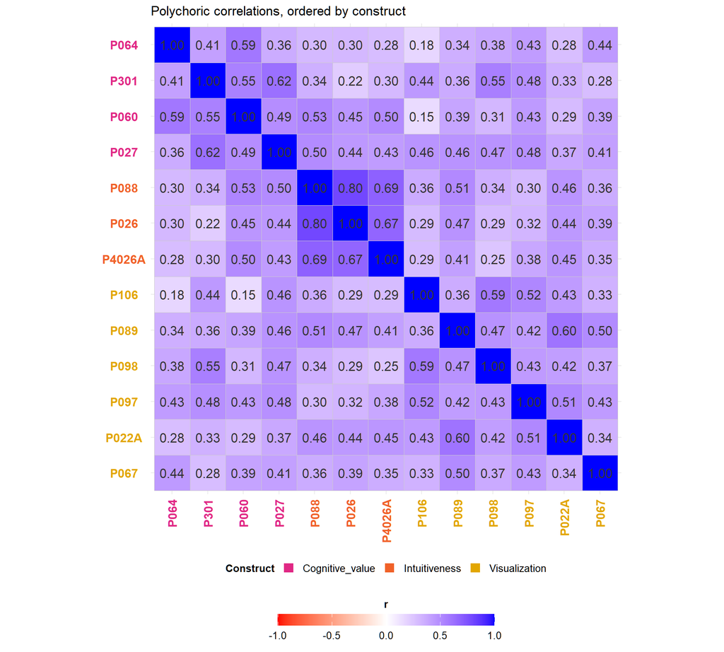

```r
plot_df <- as.data.frame(as.table(r_mat)) %>%
  rename(item1 = Var1, item2 = Var2, r = Freq) %>%
  mutate(item1 = factor(item1, levels = all_items),
         item2 = factor(item2, levels = rev(all_items)))

# axis label colour per item, in the same order as the axis ticks (x = all_items,
# y = rev(all_items))
item_colors_construct <- group_colors[groups_vec]

# a real "construct" legend requires a real aesthetic mapping — this dummy layer
# is invisible (alpha = 0) but its legend key is forced visible via override.aes,
# giving a colour-swatch legend for the axis label colours
construct_legend_df <- data.frame(
  item1 = factor(all_items[1], levels = levels(plot_df$item1)),
  item2 = factor(all_items[1], levels = levels(plot_df$item2)),
  construct = factor(names(group_colors), levels = names(group_colors))
)

p_heat_construct <- ggplot(plot_df, aes(item1, item2, fill = r)) +
  geom_tile(color = "grey80") +
  geom_text(aes(label = sprintf("%.2f", r)), size = 4.5, colour = "grey20") +
  scale_fill_gradient2(
    low = "red", mid = "white", high = "blue",
    midpoint = 0, limits = c(-1, 1), na.value = "grey95"
  ) +
  geom_point(data = construct_legend_df, aes(x = item1, y = item2, colour = construct),
             alpha = 0, inherit.aes = FALSE) +
  scale_colour_manual(name = "Construct", values = group_colors) +

  # Eliane - size of internal label
  guides(
    colour = guide_legend(override.aes = list(alpha = 1, size = 4, shape = 15), nrow = 1, order = 1),
    fill = guide_colorbar(title.position = "top", title.hjust = 0.5, barwidth = 15, barheight = 0.8, order = 2)
  ) +


 # guides(colour = guide_legend(override.aes = list(alpha = 1, size = 4, shape = 15))) + # Eliane -
  coord_fixed() +
  theme_minimal() +
  theme(
    axis.text.x = axis_text_element(item_colors_construct, angle = 90, hjust = 1, vjust = 0.5),
    axis.text.y = axis_text_element(rev(item_colors_construct), size = 12),

    legend.position = "bottom",
    legend.direction = "horizontal",
    legend.box = "vertical", # Eliane - bottom legend - gradient colors


    legend.text  = element_text(size = 10),
    legend.title = element_text(size = 10, face = "bold")

  ) +


  labs(
    title = "Polychoric correlations, ordered by construct",
    x = NULL, y = NULL, fill = "r"
  )
p_heat_construct
```

```r
# --- save PNG to include in paper ---
ggsave(
  filename = file.path(output_dir, "heatmap_construct.png"),
  plot = p_heat_construct,
  width = 10,
  height = 9,
  dpi = 300
)
```

## Hierarchical clustering of items

Distance is `1 - r`: items that move together are placed close together. Now that the negatively-worded SUS items are reverse-coded, `r` is directly comparable in sign across the whole matrix, so the plain (non-absolute) distance is the right one to use. This is agnostic to construct labels; it is purely data-driven, then compared against the intended construct assignment.

```r
dist_mat <- as.dist(1 - r_mat)
hc <- hclust(dist_mat, method = "average")

k <- length(item_groups)
empirical_cluster <- cutree(hc, k = k)

cat("Empirical cluster (k =", k, ") vs. intended construct:\n")
```

```
## Empirical cluster (k = 3 ) vs. intended construct:
```

```r
table(cluster = empirical_cluster, construct = groups_vec)
```

```
##        construct
## cluster Cognitive_value Intuitiveness Visualization
##       1               2             0             1
##       2               2             0             3
##       3               0             3             2
```

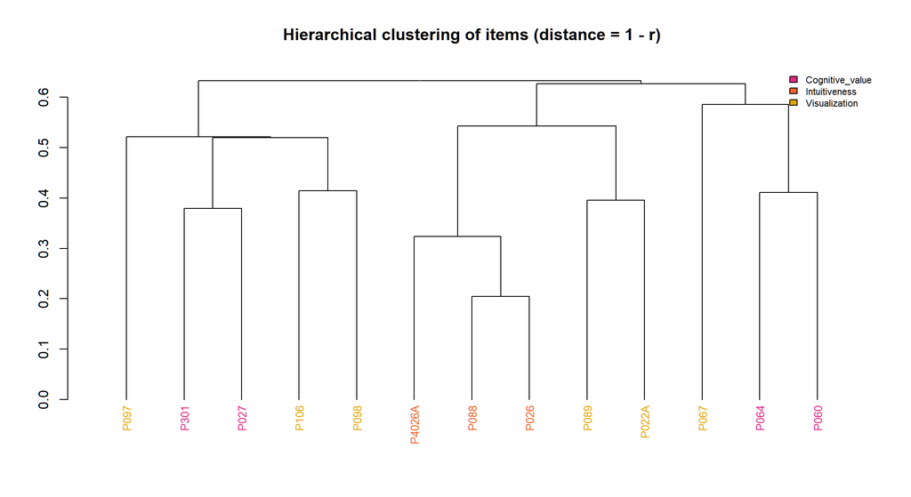

```r
plot_dendrogram <- function() {
  if (requireNamespace("dendextend", quietly = TRUE)) {
    dend <- as.dendrogram(hc)
    label_order <- labels(dend)
    dend <- dendextend::set(dend, "labels_col",
                             group_colors[groups_vec[match(label_order, colnames(r_mat))]])
    dend <- dendextend::set(dend, "labels_cex", 0.8)
    plot(dend, main = "Hierarchical clustering of items (distance = 1 - r)")
    legend("topright", legend = names(group_colors), fill = group_colors,
           cex = 0.7, bty = "n")
  } else {
    plot(hc, hang = -1, xlab = "", sub = "",
         main = "Hierarchical clustering of items (distance = 1 - r)")
    mtext("install.packages('dendextend') for construct-colored labels", side = 1, cex = 0.7)
  }
}
plot_dendrogram()
```

```r
# --- PNG (ideal to include in docs ---
png(file.path(output_dir, "dendrogram.png"), width = 10, height = 8, units = "in", res = 300)
plot_dendrogram()
dev.off()
```

## Heatmap — reordered by empirical clustering

Same matrix, same values — just reordered by `hc$order` instead of the intended construct grouping, so you can visually compare the two structures.

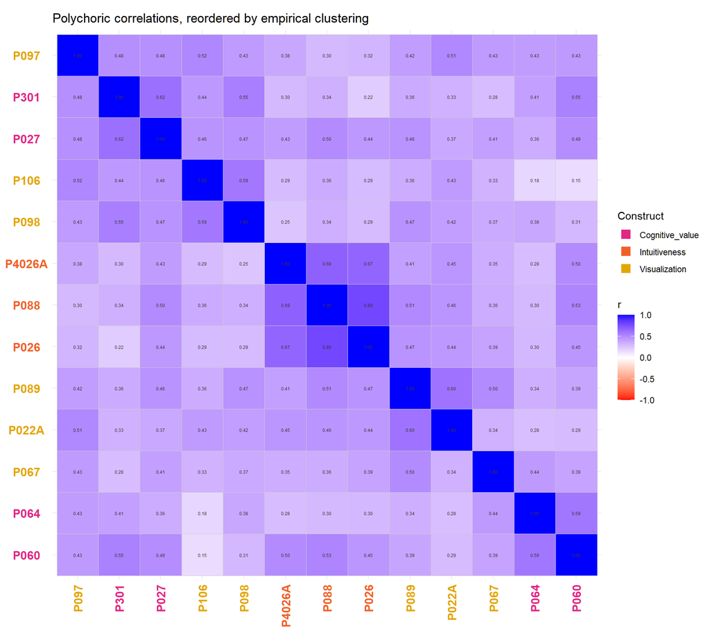

```r
cluster_order <- colnames(r_mat)[hc$order]

plot_df_cluster <- as.data.frame(as.table(r_mat)) %>%
  rename(item1 = Var1, item2 = Var2, r = Freq) %>%
  mutate(item1 = factor(item1, levels = cluster_order),
         item2 = factor(item2, levels = rev(cluster_order)))

item_colors_cluster <- group_colors[groups_vec[match(cluster_order, colnames(r_mat))]]

construct_legend_df_cluster <- data.frame(
  item1 = factor(cluster_order[1], levels = levels(plot_df_cluster$item1)),
  item2 = factor(cluster_order[1], levels = levels(plot_df_cluster$item2)),
  construct = factor(names(group_colors), levels = names(group_colors))
)

p_heat_cluster <- ggplot(plot_df_cluster, aes(item1, item2, fill = r)) +
  geom_tile(color = "grey80") +
  geom_text(aes(label = sprintf("%.2f", r)), size = 1.6, colour = "grey20") +
  scale_fill_gradient2(
    low = "red", mid = "white", high = "blue",
    midpoint = 0, limits = c(-1, 1), na.value = "grey95"
  ) +
  geom_point(data = construct_legend_df_cluster, aes(x = item1, y = item2, colour = construct),
             alpha = 0, inherit.aes = FALSE) +
  scale_colour_manual(name = "Construct", values = group_colors) +
  guides(colour = guide_legend(override.aes = list(alpha = 1, size = 4, shape = 15))) +
  coord_fixed() +
  theme_minimal() +
  theme(
    axis.text.x = axis_text_element(item_colors_cluster, angle = 90, hjust = 1, vjust = 0.5),
    axis.text.y = axis_text_element(rev(item_colors_cluster))
  ) +
  labs(
    title = "Polychoric correlations, reordered by empirical clustering",
    x = NULL, y = NULL, fill = "r"
  )
p_heat_cluster
```

```r
# --- save PNG to include in paper ---
ggsave(
  filename = file.path(output_dir, "heatmap_empirical_cluster.png"),
  plot = p_heat_cluster,
  width = 10,
  height = 9,
  dpi = 300
)
```

## Save outputs (CSV + PDF)

```r
write.csv(r_mat, file.path(output_dir, "polychoric_correlation_matrix_r.csv"))
write.csv(p_mat, file.path(output_dir, "polychoric_correlation_matrix_p.csv"))
write.csv(n_mat, file.path(output_dir, "polychoric_correlation_matrix_n.csv"))
write.csv(long, file.path(output_dir, "polychoric_correlation_long.csv"), row.names = FALSE)





pdf(file.path(output_dir, "polychoric_correlation_matrices.pdf"), width = 10, height = 9)
print(p_heat_construct)
print(p_heat_cluster)
plot_dendrogram()
invisible(dev.off())
```